### UNIVERSIDAD NACIONAL AUTÓNOMA DE MÉXICO

# DDA: COMPARACIÓN DE CADENAS

### Hecha por: Ramón Daniel Cota Aguiar

Para un alfabeto de dos símbolos ($0,1$) ($M=2$), secuencias de longitud $L = 20$ y $R = [1,2,3,4,5,..., 15]$ calcular $P_m$ en función de $R$ para dos casos:

- Con desplazamiento
- Sin desplazamiento

Para cada valor $R$, llevar a cabo $K=30$ experimentos $MC$:

- Sean $S_0$ y $S_1$ dos secuencias de longitur $L$ generada al azar a partir de los $M$ símbolos en el alfabeto. Comparar ¿Existe una secuencia de $R$ posiciones que coincidan?

La probabilidad $P_M(R)$ es el número de secuencias para las cuáles la respuesta a la pregunta es verdadera dividida entre $K$.

[figure not shown]

```python
import random
from collections import Counter
from tabulate import tabulate
import pandas as pd
import matplotlib.pyplot as plt
```

## Secuencias de ejemplo

Primero hacemos pruebas creando un solo par de secuencias a las que llamaremos **secuence0** ($S_0$) y **secuence1** ($S_1$). Estas se generarán eligiendo de manera aleatoria los elementos del alfabeto que en este caso son [$0,1$].

```python
secuence_0 = []
for i in range(0,20):
    secuence_0.append(random.randint(0,1))

secuence_1 = []
for i in range(0,20):
    secuence_1.append(random.randint(0,1))

print("SECUENCIAS DE EJEMPLO: ")
print("\n", secuence_0)
print("\n", secuence_1)
```

```
SECUENCIAS DE EJEMPLO:

 [1, 0, 0, 0, 0, 1, 1, 0, 0, 0, 0, 1, 0, 1, 0, 0, 1, 0, 0, 1]

 [0, 1, 0, 1, 0, 1, 1, 1, 0, 0, 0, 0, 0, 0, 1, 0, 0, 1, 0, 0]
```

## Comparación Sin Desplazamiento

Se comparan ambas secuencias para identificar si existe algún patrón binario en común de longitud $R = [1,2,3,...,15]$. Para ello hacemos un barrido que comparará los índices de las listas. En donde se comparará el mismo índice de uno con el del otro.

```python
lista_sm = []
for i in range(0,20):
    for j in range(i+1,21):
        if secuence_0[i:j] == secuence_1[i:j]:
            lista_sm.append(len(secuence_0[i:j]))
            lista_sm.sort()
print(lista_sm)
```

```
[1, 1, 1, 1, 1, 1, 1, 1, 1, 1, 2, 2, 2, 2, 3, 3]
```

## Comparación Con Desplazamiento

Ahora se compararán las dos secuencias, pero una se desplazará y comparará si existe alguna secuencia de longitud $R$ con ese nuevo desplazamiento.

```python
lista_cm = []
for i in range(1,16):
    for j in range(0,21-i):
        for k in range(0,21-i):
            if secuence_0[j:j+i] == secuence_1[k:k+i]:
                lista_cm.append(len(secuence_1[k:k+i]))
print(lista_cm)
```

[output not shown]

## FUNCIONES

```python
def unique(list1):
    """
    Debido a que las listas guardarán la longitud de R cada vez que estas coincidan, habrá al final una lista de números repetidos
    debido a que R puede coincidir más de una vez. Por lo tanto, si nuestra lista fuera: L = [1,1,1,2,2,3]. Regresaría una lista L_return = [1,2,3].
    :param list1: Debe ser una lista con únicamente valores numéricos.
    :return: unique_list: Una lista de únicamente los valores repetidos.
    """
    list_set = set(list1)
    unique_list = (list(list_set))
    return unique_list

print("Prueba de la función")
print("Lista de coincidencias de R: \t", lista_sm)
print("Lista con la función unique: \t", unique(lista_sm))
```

[output not shown]

```python
def monte_carlo(montecarlo):
    """
    Esta función repite los experimentos las veces que la variable montecarlo indique.

    Se comienzan por 2 listas vacías que se llenarán con el valor de R, es decir, el número de posiciones contiguas en las que coinciden las secuencias secuence_0 y secuence_1. Para ello se hace primero un barrido de las secuencias índice(s) por índice(s). Es decir, se compararán secuence_0[R] y secuence[R]. Posterior a esto se guardan las R en que coindicen y se realiza la comparación pero ahora con R desplazada. Es decir, secuence_0[R] con secuence_1[R+i], siendo i cualquier valor entre 0 y 20 en el menor valor de R y 0 y 5 en el mayor valor de R.
    :param montecarlo: Número de veces que se repetirá el experimento.
    :return: listas ordenadas de R coincidentes.
    """
    lista_sm = []
    lista_cm = []
    # montecarlo = 30
    for l in range(0,montecarlo):
        secuence_0 = []
        for i in range(0,20):
            secuence_0.append(random.randint(0,1))

        secuence_1 = []
        for i in range(0,20):
            secuence_1.append(random.randint(0,1))

        ########
        lista2 = []
        for i in range(0,20):
            for j in range(i+1,21):
                if secuence_0[i:j] == secuence_1[i:j]:
                    lista2.append(len(secuence_0[i:j]))
                    lista2.sort()
        # lista_sm.append(max(lista2))
        lista_sm.append(unique(lista2))
        lista_sm.sort()
        ########
        lista3 = []
        for i in range(1,16):
            for j in range(0,21-i):
                for k in range(0,21-i):
                    if secuence_0[j:j+i] == secuence_1[k:k+i]:
                        lista3.append(len(secuence_1[k:k+i]))
        # lista_cm.append(max(lista3))
        lista_cm.append(unique(lista3))
        lista_cm.sort()
    return lista_sm, lista_cm

print("Prueba de la función realizada 3 veces")
lista_sm, lista_cm = monte_carlo(3)
print("\n Lista Sin Desplazamiento:\t", lista_sm)
print("\n Lista Con Desplazamiento:\t", lista_cm)
```

```
Prueba de la función realizada 3 veces

 Lista Sin Desplazamiento:	 [[1, 2], [1, 2, 3], [1, 2, 3]]

 Lista Con Desplazamiento:	 [[1, 2, 3, 4, 5, 6], [1, 2, 3, 4, 5, 6], [1, 2, 3, 4, 5, 6, 7, 8, 9]]
```

```python
def list_hist(lista_de_listas, montecarlo):
    """
    Al ser una lista de listas, debemos extraer cada lista externa para hacer una lista total de todas las R coincidentes.
    :param lista_de_listas:
    :return: lista de elementos de la lista.
    """
    lista = []
    for r in range(0,montecarlo):
        for p in range(0,len(lista_de_listas[r])):
            lista.append(lista_de_listas[r][p])
    lista.sort()
    return lista

print("Comparativo de prueba")
print("Lista de listas de R realizado 3 veces: ")
print("\n", lista_sm)
print("\nLista solo con las R de todas las repeticiones")
print("\n", list_hist(lista_sm,3))
```

```
Comparativo de prueba
Lista de listas de R realizado 3 veces:

 [[1, 2], [1, 2, 3], [1, 2, 3]]

Lista solo con las R de todas las repeticiones

 [1, 1, 1, 2, 2, 2, 3, 3]
```

```
   R |   frecuencia
-----+--------------
   1 |            3
   2 |            3
   3 |            2
```

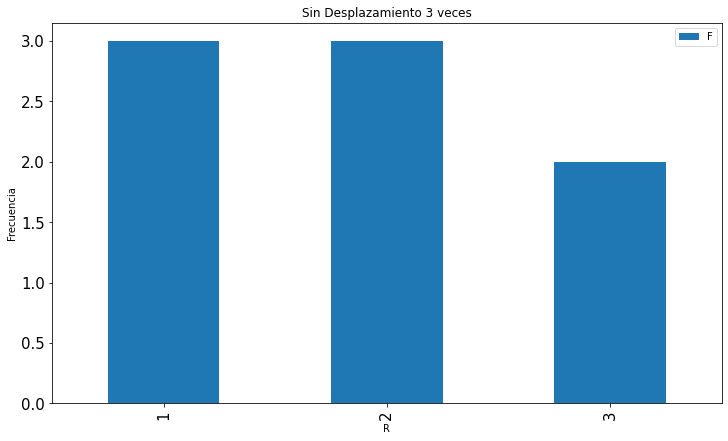

```python
def tab_plt_hist(lista_cm,montecarlo,Title):
    """
    Función para crear el DataFrame e imprimir tanto la tabla como el histograma.
    :param lista_cm:lista de listas
    :param montecarlo: número de veces que se realizaron.
    :return:DataFrame
    """
    list_counter = Counter(list_hist(lista_cm,montecarlo))
    df = pd.DataFrame.from_dict(list_counter, orient = 'index')
    print(tabulate(df,headers=['R', 'frecuencia'],tablefmt="presto"))
    df.plot(kind='bar', figsize=(12, 7),  fontsize=15,title = Title + " " + str(montecarlo) + " veces" )
    plt.legend('Frecuencia')
    plt.xlabel('R')
    plt.ylabel('Frecuencia')
    return df

df = tab_plt_hist(lista_sm,3,"Sin Desplazamiento")
```

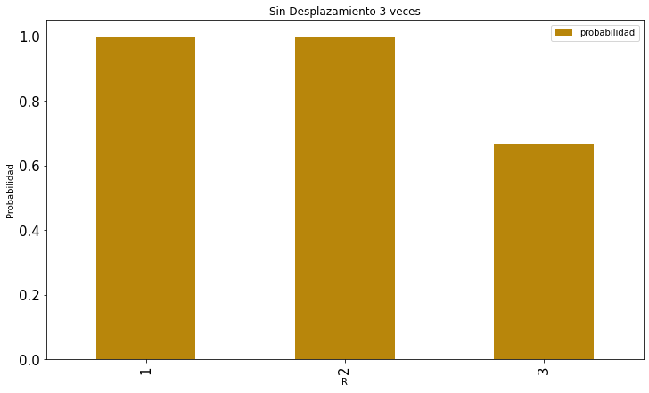

```python
def porcentaje_hist(df, montecarlo,  Title):
    """
    Función para plotear el histograma con los porcentajes para cada R.
    """
    lista = []
    suma_total = montecarlo
    for i in (df[0]):
        lista.append(i/suma_total)
    df['probabilidad'] = lista
    df.plot(kind='bar', y = 'probabilidad', figsize=(12, 7),  fontsize=15, facecolor='darkgoldenrod')
    plt.title(Title + " " + str(montecarlo) + " veces")
    plt.xlabel('R')
    plt.ylabel('Probabilidad')

porcentaje_hist(df,3,"Sin Desplazamiento")
```

## RESULTADOS

```python
montecarlo = 30
lista_sm, lista_cm = monte_carlo(montecarlo)
```

```
   R |   frecuencia
-----+--------------
   1 |           30
   2 |           30
   3 |           30
   4 |           30
   5 |           30
   6 |           27
   7 |           18
   8 |            6
   9 |            2
```

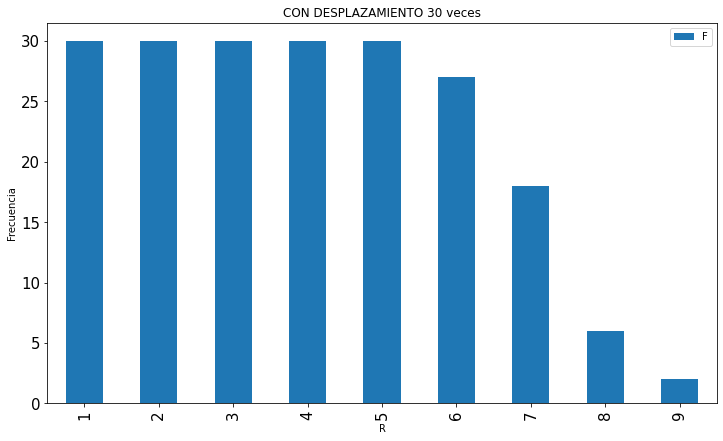

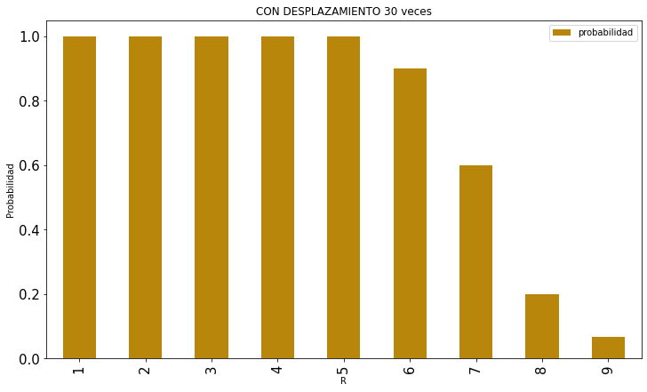

```python
df = tab_plt_hist(lista_cm,montecarlo,"CON DESPLAZAMIENTO")
porcentaje_hist(df,montecarlo, "CON DESPLAZAMIENTO")
```

```
   R |   frecuencia
-----+--------------
   1 |           30
   2 |           29
   3 |           23
   4 |           13
   5 |            8
   6 |            3
   7 |            1
```

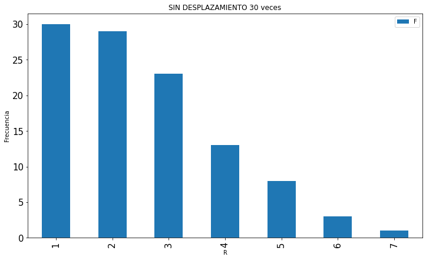

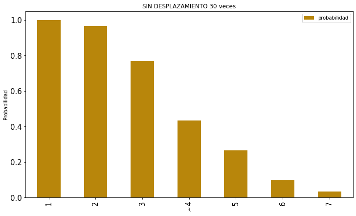

```python
df = tab_plt_hist(lista_sm,montecarlo,'SIN DESPLAZAMIENTO')
porcentaje_hist(df,montecarlo, 'SIN DESPLAZAMIENTO')
```